# Final assignment: Numerical simulation 2016

## Oil prices: do they affect inflation?

Edgar Brouwer (430777), Nick Goedhart (405071) & Arjan Spaans (181637)

# Research question

Low inflation in France: to what extent are low oil prices responsible?

## Motivation

During the early 2000s until 2008 oil prices hit all-time heights, but when the financial crisis hit however, the price of oil declined sharply and also from last year until now many commodities have seen sharp declining prices. The inflation rate in the Eurozone has also fallen during the last three years. In the year 2012 the inflation was on the five-year average of about 2.5% while now it is around only around one percent. Since oil has seen its prices decrease at similar rates as the inflation, the question occurs whether the changes in oil prices affect the inflation rate. Answering this question and thus understanding the linkage between oil prices and inflation is not only vital for monetary policy makers for conducting sound monetary policies but also for firm managers since if oil prices affect the prices of production, prices of goods need to be changed as well. Additionally, most research regarding the effect of oil prices on inflation is outdated since it does not take into account the post-financial crisis price decreases. Most of the research is done for the US instead of the Eurozone and researchers typically are interested in price increases instead of decreases that we saw during the last few years.

## Answer

Although it is striaghtforward to believe that oil prices have a direct and indirect effect on inflation we did not manage to find statistical evidence for this effect in the first model used.

Further research using different models (for instance models that investigate a non-linear trend) is adviced. Also we did not consider time lags in our analysis what can be of great importance in time series analysis.

## Method

In order to investigate this topic, we worked with time series data from 1987-2015 which we downloaded from the website of the French National Bank and [OECD Stat](http://stats.oecd.org). Although the main focus of our study is on the impact of oil price changes on inflation specifically, we included some control variables: unemployment rate (Unemp), broad money supply (M3) and differences in exchange rate (Dolleur). In order to assure that the variables were stationary, we used the log differences for the variables in numbers (CPI, M3 money supply and oil prices) while leaving the variables that are rates untouched. This leads to the following regression:

$Difinfl_t = \beta_1DifOil_t + \beta_2Interest_t + \beta_3Unemp_t + \beta_4Dolleur + \beta_5Difm3 + \epsilon_t$

We used the Pandas module in Python to analyse the data.

## Assumptions

In order for this model to produce good estimates, the Gauss-Markov assumptions need to hold. These are listed [here](http://econweb.rutgers.edu/tsurumi/blue1.pdf). For the purpose of this assignment, we only tested for stationarity using the Dickey-Fuller Test.

## Importing libraries and data

In this assignment we use the following packages.

```python
import pandas as pd
import numpy as np
import matplotlib.pylab as plt
%matplotlib inline
from matplotlib.pylab import rcParams
rcParams['figure.figsize'] = 15, 6
```

## Data

As mentioned before the data concerning Frech financial statistics are drawn from the French National Bank while other data are from [OECD Stat](http://stats.oecd.org). The time series data has a timespan from 1987-07-01, what was the first date at which we could retreive data concerning the Brent oil price, till the most recent data we could acquire at 2016-01-01.

Below is an example of the first five quarters in our dataset:

```python
data = pd.read_csv('numisa1.csv')
print data.head()
print '\n Data Types:'
print data.dtypes
```

```
      Quarter  Unemp  Brent   CPI  Interest      m3  Dolleur  Oillndif  \
0  1987-07-01  8.703  19.06  66.1     7.917  534657    0.935       NaN
1  1987-10-01  8.648  17.87  66.5     8.510  564034    0.877  -0.06447
2  1988-01-01  8.579  15.66  66.9     7.943  555254    0.864  -0.13201
3  1988-04-01  8.445  16.13  67.6     7.750  568587    0.881   0.02957
4  1988-07-01  8.442  14.33  68.2     7.657  581039    0.963  -0.11833

     Difin   m3dif
0      NaN     NaN
1  0.00603  0.0535
2  0.00600 -0.0157
3  0.01041  0.0237
4  0.00884  0.0217

 Data Types:
Quarter      object
Unemp       float64
Brent       float64
CPI         float64
Interest    float64
m3            int64
Dolleur     float64
Oillndif    float64
Difin       float64
m3dif       float64
dtype: object
```

In this section we make pandas aware that we use time series data:

```python
dateparse = lambda dates: pd.datetime.strptime(dates, '%Y-%m-%d')
data = pd.read_csv('numisa1.csv', parse_dates='Quarter', index_col='Quarter',date_parser=dateparse)
print data.head()
```

```
            Unemp  Brent   CPI  Interest      m3  Dolleur  Oillndif    Difin  \
Quarter
1987-07-01  8.703  19.06  66.1     7.917  534657    0.935       NaN      NaN
1987-10-01  8.648  17.87  66.5     8.510  564034    0.877  -0.06447  0.00603
1988-01-01  8.579  15.66  66.9     7.943  555254    0.864  -0.13201  0.00600
1988-04-01  8.445  16.13  67.6     7.750  568587    0.881   0.02957  0.01041
1988-07-01  8.442  14.33  68.2     7.657  581039    0.963  -0.11833  0.00884

             m3dif
Quarter
1987-07-01     NaN
1987-10-01  0.0535
1988-01-01 -0.0157
1988-04-01  0.0237
1988-07-01  0.0217
```

```python
data.index
```

```
DatetimeIndex(['1987-07-01', '1987-10-01', '1988-01-01', '1988-04-01',
               '1988-07-01', '1988-10-01', '1989-01-01', '1989-04-01',
               '1989-07-01', '1989-10-01',
               ...
               '2013-10-01', '2014-01-01', '2014-04-01', '2014-07-01',
               '2014-10-01', '2015-01-01', '2015-04-01', '2015-07-01',
               '2015-10-01', '2016-01-01'],
              dtype='datetime64[ns]', name=u'Quarter', length=115, freq=None)
```

```python
ts = data['Difin']
ts.head(115)
```

```
Quarter
1987-07-01        NaN
1987-10-01    0.00603
1988-01-01    0.00600
1988-04-01    0.01041
1988-07-01    0.00884
1988-10-01    0.00730
1989-01-01    0.00725
1989-04-01    0.00863
1989-07-01    0.00714
1989-10-01    0.00709
1990-01-01    0.00563
1990-04-01    0.01117
1990-07-01    0.00692
1990-10-01    0.00824
1991-01-01    0.00953
1991-04-01    0.00810
1991-07-01    0.00670
1991-10-01    0.00930
1992-01-01    0.00791
1992-04-01    0.00914
1992-07-01    0.00519
1992-10-01    0.00516
1993-01-01    0.00897
1993-04-01    0.00762
1993-07-01    0.00379
1993-10-01    0.00378
1994-01-01    0.00501
1994-04-01    0.00499
1994-07-01    0.00372
1994-10-01    0.00371
               ...
2008-10-01    0.00408
2009-01-01    0.00102
2009-04-01    0.00709
2009-07-01    0.00101
2009-10-01    0.00101
2010-01-01    0.00201
2010-04-01    0.00501
2010-07-01    0.00200
```

[output cut: 8 more lines]

```
2012-10-01    0.00097
2013-01-01   -0.00097
2013-04-01    0.00776
2013-07-01    0.00097
2013-10-01    0.00096
2014-01-01    0.00193
2014-04-01    0.00671
2014-07-01    0.00000
2014-10-01   -0.00096
2015-01-01   -0.00192
2015-04-01    0.00859
2015-07-01    0.00095
2015-10-01   -0.00095
2016-01-01        NaN
Name: Difin, dtype: float64
```

```python
ts1 = data['Oillndif']
ts.head(115)
```

```
Quarter
1987-07-01        NaN
1987-10-01    0.00603
1988-01-01    0.00600
1988-04-01    0.01041
1988-07-01    0.00884
1988-10-01    0.00730
1989-01-01    0.00725
1989-04-01    0.00863
1989-07-01    0.00714
1989-10-01    0.00709
1990-01-01    0.00563
1990-04-01    0.01117
1990-07-01    0.00692
1990-10-01    0.00824
1991-01-01    0.00953
1991-04-01    0.00810
1991-07-01    0.00670
1991-10-01    0.00930
1992-01-01    0.00791
1992-04-01    0.00914
1992-07-01    0.00519
1992-10-01    0.00516
1993-01-01    0.00897
1993-04-01    0.00762
1993-07-01    0.00379
1993-10-01    0.00378
1994-01-01    0.00501
1994-04-01    0.00499
1994-07-01    0.00372
1994-10-01    0.00371
               ...
2008-10-01    0.00408
2009-01-01    0.00102
2009-04-01    0.00709
2009-07-01    0.00101
2009-10-01    0.00101
2010-01-01    0.00201
2010-04-01    0.00501
2010-07-01    0.00200
```

[output cut: 8 more lines]

```
2012-10-01    0.00097
2013-01-01   -0.00097
2013-04-01    0.00776
2013-07-01    0.00097
2013-10-01    0.00096
2014-01-01    0.00193
2014-04-01    0.00671
2014-07-01    0.00000
2014-10-01   -0.00096
2015-01-01   -0.00192
2015-04-01    0.00859
2015-07-01    0.00095
2015-10-01   -0.00095
2016-01-01        NaN
Name: Difin, dtype: float64
```

And the respective graphs over time:

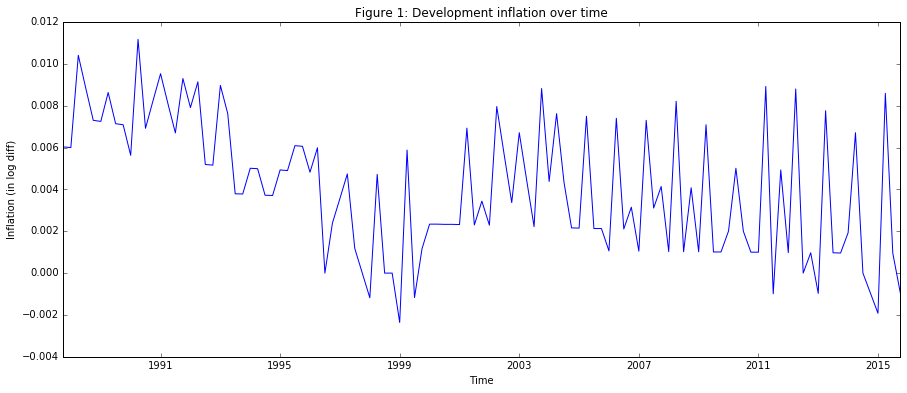

```python
plt.plot(ts)
plt.ylabel('Inflation (in log diff)')
plt.xlabel('Time')
plt.title('Figure 1: Development inflation over time')
plt.savefig('Devinflation.png')
```

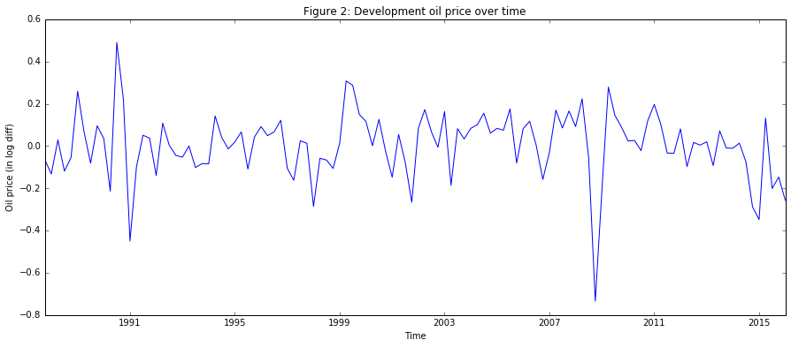

```python
plt.plot(ts1)
plt.ylabel('Oil price (in log diff)')
plt.xlabel('Time')
plt.title('Figure 2: Development oil price over time')
plt.savefig('devoil.png')
```

The below two graphs show the CPI index development and the development of oil prices in our data set. We can see that CPI increase less in the tail of the data set while the sharp decline in oil prices during the last year.

```python
ts2 = data['CPI']
ts3 = data['Brent']
```

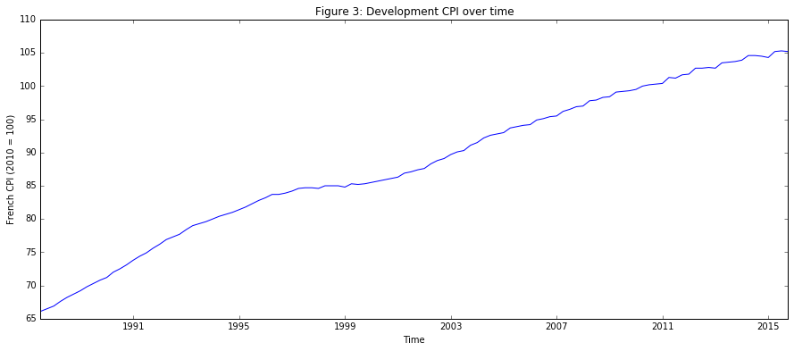

```python
plt.plot(ts2)
plt.ylabel('French CPI (2010 = 100)')
plt.xlabel('Time')
plt.title('Figure 3: Development CPI over time')
plt.savefig('devoil.png')
```

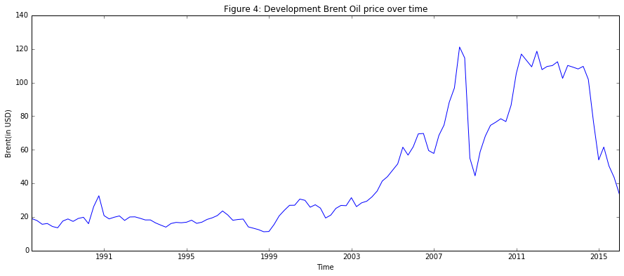

```python
plt.plot(ts3)
plt.ylabel('Brent(in USD)')
plt.xlabel('Time')
plt.title('Figure 4: Development Brent Oil price over time')
plt.savefig('devoil.png')
```

Now we will check for stationarity for two variables namely the log difference for inflation and the log difference in oil prices.

```python
from statsmodels.tsa.stattools import adfuller
def test_stationarity(timeseries):

    #Lines for determination of rolling statistics
    rolmean = pd.rolling_mean(timeseries, window=12)
    rolstd = pd.rolling_std(timeseries, window=12)

    #Lines used for plotting rolling statistics:
    orig = plt.plot(timeseries, color='blue',label='Original')
    mean = plt.plot(rolmean, color='red', label='Rolling Mean')
    std = plt.plot(rolstd, color='black', label = 'Rolling Std')
    plt.legend(loc='best')
    plt.title('Rolling Mean & Standard Deviation')
    plt.show(block=False)

    #Lines used for performing the Dickey-Fuller test:
    print 'Results of Dickey-Fuller Test:'
    dftest = adfuller(timeseries, autolag='AIC')
    dfoutput = pd.Series(dftest[0:4], index=['Test Statistic','p-value','#Lags Used','Number of Observations Used'])
    for key,value in dftest[4].items():
        dfoutput['Critical Value (%s)'%key] = value
    print dfoutput
```

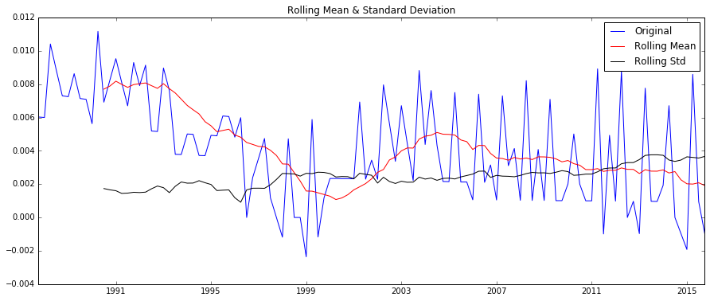

```
Results of Dickey-Fuller Test:
Test Statistic                  -1.770130
p-value                          0.395389
#Lags Used                      11.000000
Number of Observations Used    101.000000
Critical Value (5%)             -2.890611
Critical Value (1%)             -3.496818
Critical Value (10%)            -2.582277
dtype: float64
```

```python
test_stationarity(ts['1987-10-01':'2015-10-01'])
```

For the difference in Oil in the graph below, we can firmly confirm that this variable is stationary.

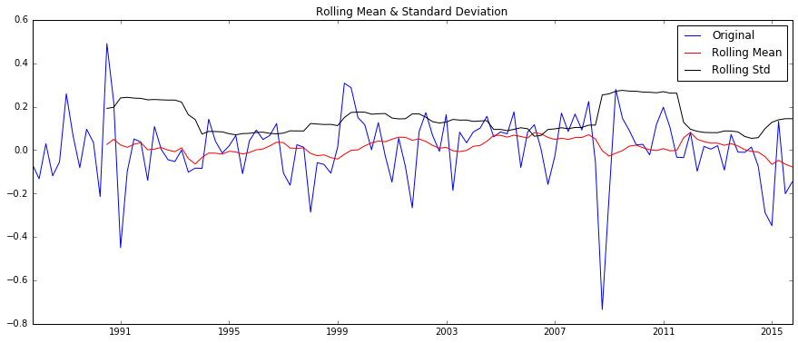

```
Results of Dickey-Fuller Test:
Test Statistic                -8.740206e+00
p-value                        3.023266e-14
#Lags Used                     1.000000e+00
Number of Observations Used    1.110000e+02
Critical Value (5%)           -2.887952e+00
Critical Value (1%)           -3.490683e+00
Critical Value (10%)          -2.580857e+00
dtype: float64
```

```python
test_stationarity(ts1['1987-10-01':'2015-10-01'])
```

Below, we will start with the OLS analysis after importing some tools.

```python
import statsmodels.formula.api as sm
result = sm.ols(formula="Difin ~ Oillndif + Interest + Unemp + Dolleur + m3dif", data=data).fit()
print result.params
```

```
Intercept    0.004990
Oillndif     0.001816
Interest     0.000531
Unemp       -0.000179
Dolleur     -0.002010
m3dif        0.016967
dtype: float64
```

```python
print result.summary()
```

```
                            OLS Regression Results
==============================================================================
Dep. Variable:                  Difin   R-squared:                       0.345
Model:                            OLS   Adj. R-squared:                  0.314
Method:                 Least Squares   F-statistic:                     11.18
Date:                Wed, 13 Apr 2016   Prob (F-statistic):           1.14e-08
Time:                        14:48:54   Log-Likelihood:                 509.38
No. Observations:                 112   AIC:                            -1007.
Df Residuals:                     106   BIC:                            -990.4
Df Model:                           5
Covariance Type:            nonrobust
==============================================================================
                 coef    std err          t      P>|t|      [95.0% Conf. Int.]
------------------------------------------------------------------------------
Intercept      0.0050      0.002      2.259      0.026         0.001     0.009
Oillndif       0.0018      0.002      1.125      0.263        -0.001     0.005
Interest       0.0005   7.81e-05      6.795      0.000         0.000     0.001
Unemp         -0.0002      0.000     -1.346      0.181        -0.000  8.48e-05
Dolleur       -0.0020      0.002     -0.889      0.376        -0.006     0.002
m3dif          0.0170      0.015      1.115      0.267        -0.013     0.047
==============================================================================
Omnibus:                        4.772   Durbin-Watson:                   2.264
Prob(Omnibus):                  0.092   Jarque-Bera (JB):                4.785
Skew:                           0.500   Prob(JB):                       0.0914
Kurtosis:                       2.844   Cond. No.                         597.
==============================================================================

Warnings:
[1] Standard Errors assume that the covariance matrix of the errors is correctly specified.
```

The results above show no significant relationship between changes in oil prices and the French CPI. A clarification for this can be structural breaks which are explained [here](http://people.bu.edu/perron/712/0204046.pdf) on page 2743 for example. A structural break could have occured around the [Opec Collapse in 1986](http://www.brookings.edu/~/media/Projects/BPEA/1986-2/1986b_bpea_gately_adelman_griffin.PDF). A way of dealing with this is removing the first years of data from the sample which we do below. In this smaller dataset we use data ranging from the start of 1995 till the end of 2015.

```python
data = pd.read_csv('numisa12.csv')
print data.head()
print '\n Data Types:'
print data.dtypes
```

```
      Quarter  Unemp  Brent   CPI  Interest      m3  Dolleur  Oillndif  \
0  1995-01-01  9.866  16.89  81.4     6.583  792927    0.788   0.01973
1  1995-04-01  9.661  18.07  81.8     7.587  813173    0.750   0.06753
2  1995-07-01  9.488  16.21  82.3     6.180  822424    0.754  -0.10862
3  1995-10-01  9.602  16.92  82.8     6.100  841149    0.752   0.04287
4  1996-01-01  9.954  18.56  83.2     4.397  827823    0.768   0.09251

     Difin   m3dif
0  0.00493  0.0163
1  0.00490  0.0252
2  0.00609  0.0113
3  0.00606  0.0225
4  0.00482 -0.0160

 Data Types:
Quarter      object
Unemp       float64
Brent       float64
CPI         float64
Interest    float64
m3            int64
Dolleur     float64
Oillndif    float64
Difin       float64
m3dif       float64
dtype: object
```

```python
dateparse = lambda dates: pd.datetime.strptime(dates, '%Y-%m-%d')
data = pd.read_csv('numisa12.csv', parse_dates='Quarter', index_col='Quarter',date_parser=dateparse)
print data.head()
```

```
            Unemp  Brent   CPI  Interest      m3  Dolleur  Oillndif    Difin  \
Quarter
1995-01-01  9.866  16.89  81.4     6.583  792927    0.788   0.01973  0.00493
1995-04-01  9.661  18.07  81.8     7.587  813173    0.750   0.06753  0.00490
1995-07-01  9.488  16.21  82.3     6.180  822424    0.754  -0.10862  0.00609
1995-10-01  9.602  16.92  82.8     6.100  841149    0.752   0.04287  0.00606
1996-01-01  9.954  18.56  83.2     4.397  827823    0.768   0.09251  0.00482

             m3dif
Quarter
1995-01-01  0.0163
1995-04-01  0.0252
1995-07-01  0.0113
1995-10-01  0.0225
1996-01-01 -0.0160
```

```python
import statsmodels.formula.api as sm
result = sm.ols(formula="Difin ~ Oillndif + Interest + Unemp + Dolleur + m3dif", data=data).fit()
print result.params
```

```
Intercept    0.004328
Oillndif     0.004142
Interest     0.000185
Unemp       -0.000116
Dolleur     -0.001380
m3dif        0.038624
dtype: float64
```

```python
print result.summary()
```

```
                            OLS Regression Results
==============================================================================
Dep. Variable:                  Difin   R-squared:                       0.125
Model:                            OLS   Adj. R-squared:                  0.068
Method:                 Least Squares   F-statistic:                     2.196
Date:                Wed, 13 Apr 2016   Prob (F-statistic):             0.0632
Time:                        22:30:29   Log-Likelihood:                 373.55
No. Observations:                  83   AIC:                            -735.1
Df Residuals:                      77   BIC:                            -720.6
Df Model:                           5
Covariance Type:            nonrobust
==============================================================================
                 coef    std err          t      P>|t|      [95.0% Conf. Int.]
------------------------------------------------------------------------------
Intercept      0.0043      0.002      1.770      0.081        -0.001     0.009
Oillndif       0.0041      0.002      2.032      0.046      8.39e-05     0.008
Interest       0.0002      0.000      0.982      0.329        -0.000     0.001
Unemp         -0.0001      0.000     -0.793      0.430        -0.000     0.000
Dolleur       -0.0014      0.003     -0.534      0.595        -0.007     0.004
m3dif          0.0386      0.023      1.688      0.095        -0.007     0.084
==============================================================================
Omnibus:                        3.424   Durbin-Watson:                   2.314
Prob(Omnibus):                  0.181   Jarque-Bera (JB):                3.098
Skew:                           0.390   Prob(JB):                        0.212
Kurtosis:                       2.464   Cond. No.                         682.
==============================================================================

Warnings:
[1] Standard Errors assume that the covariance matrix of the errors is correctly specified.
```

## Conclusion & Discussion

Although it took some effort to finish this assignment we made it to the final cell of this notebook. Unfortunately, the model used in this assignment does not work very well for at least the first model used. Although the coefficient for Oil is positive it is far from significant. As can be expected, the most influential independent variable is the interest rate, what is also used by monetary policy makers for controling inflation rates.